# Population Growth Rates in Differing Countries

What Factors affect a Country’s Population Growth?

Team BIC Brynna Johnson, Islay Van Dusen, and Claire Foley

December 11, 2022

# Research Question

How do factors such as a country’s GDP, health statistics, and average life expectancy affect its population growth rate?

# Data Sources

### World Population Data Set

Our first data set is a World Population Data set. It includes columns with country names and/or their abbreviations, the populations for different years (1970, 1980, 1990, 2000, 2010, 2015, 2020, and 2022), the area size of the country, the population density, the growth rate, the percentage of the world population, and the rank the country is in population size. The data comes from https://www.kaggle.com/datasets/whenamancodes/world-population-live-dataset. This is not the original data source. This data has been pre-processed from https://www.worldometers.info/world-population/ , which counts the current population. The data from Kaggle is compiled by Aman Chauhan from the worldometers website. The data from worldometers is an elaboration of data by The United Nations, the Department of Economic and Social Affairs, Population Division. The data could be slightly biased by the Democratic Republic of the Congo, Ethiopia, India, Indonesia, Nigeria, Pakistan, Uganda, the United Republic of Tanzania, and the United States of America because these countries are projected to have high growth in population in the recent and coming years. However, this may just be a trend and not biased.

### World Development Indicators by Countries Dataset

The second data set we used comes from the World Development Indicators by Countries. This data set can be found and downloaded at https://www.kaggle.com/datasets/hn4ever/world-development-indicators-by-countries. The creator of this data set is Noor B.A. and uploaded to Kaggle. From this data set, we used the health_risk_factors.csv file. This data set is originally from World Development Indicators: Health risk factors and future challenges, accessible at World Bank: http://wdi.worldbank.org/table/2.17

This data set consists of country names, the percentage of males over 15 who smoke, the percentage of females over 15 that smoke, the incidence of tuberculosis within the country, the prevalence of diabetes in the country, the number of new HIV infections, the percentage of people between 15-49 that have HIV, the percentage of females with HIV, and the percentage of males with HIV.

The health risk factors data set has NA values, which have to be removed to utilize the data. This means that data for certain countries are missing. Since some values are missing, certain conclusions could be lacking data since not all countries have data available for different variables.

### GDP in USD

This data set comes form worldbank.org. This data set gives the GDP per country in US Dollars. The original data comes from a combination of data from the world bank and OECD National Accounts data files. The data is accessible at: https://data.worldbank.org/indicator/NY.GDP.MKTP.CD. This data set contains data on the country name, the country abbreviation, the indicator name, the indicator code, and years 1960-2021 GDP data.

### Fertility Rate

This data set comes form worldbank.org. This data set gives the fertility rate of women in different countries. The original data comes from a combination of data from the world bank, world population prospects, Census reports and other statistical publications from national statistical offices, Eurostat: Demographic Statistics, United Nations Statistical Division. Population and Vital Statistics Report, U.S. Census Bureau: International Database, and Secretariat of the Pacific Community: Statistics and Demography Programme. The data is accessible at: https://data.worldbank.org/indicator/SP.DYN.TFRT.IN. This data set contains data on the country name, the country abbreviation, the indicator name, the indicator code, and years 1960-2020 of fertility data.

### Life Expectancy at Birth

This data set comes form worldbank.org. This data set gives the life expectancy data in different countries. The original data comes from a combination of data from the world bank, United Nations Population Division, World Population Prospects: 2019 Revision, or derived from male and female life expectancy at birth from sources such as: Census reports and other statistical publications from national statistical offices, Eurostat: Demographic Statistics, United Nations Statistical Division. Population and Vital Statistics Report, U.S. Census Bureau: International Database, and Secretariat of the Pacific Community: Statistics and Demography. The data is accessible at: https://data.worldbank.org/indicator/SP.DYN.LE00.IN. This data set contains data on the country name, the country abbreviation, the indicator name, the indicator code, and years 1960-2020 of life expectancy data.

# Answering the Question

## Analysis and Charts

[figure not shown]

```r
#initial charts: maps showing GDP and Growth rate by country
data1 <- health_system %>%
    clean_names() %>%
    filter((health_expenditure_current_percent_of_gdp_2016 != "NA"),
           (health_expenditure_public_percent_of_current_2016 != "NA"))


####
data2 <- worldpop %>%
    clean_names() %>%
    arrange(desc(growth_rate)) %>%
    mutate(name = fct_reorder(name, growth_rate)) %>%
    slice(1:20) %>%
    ggplot() +
    geom_col(
        aes(x = growth_rate, y = name), linewidth = 0.1, color = "black", fill = "black")




#min(worldpop$GrowthRate)
#max(worldpop$GrowthRate)


world <- ne_countries(
    scale = "medium",
    returnclass = "sf")

world_map <- world %>%
    left_join(worldpop, by = c('iso_a2' = 'CCA3'))


growth_rate_map <- ggplot(world_map) +
    geom_sf(aes(fill = GrowthRate), color = NA) +
    scale_fill_viridis_c(limits = c(0.90, 1.1))+
    guides(fill = guide_colorbar(
        title.position = "top",
        title.hjust = 0.5,
        barwidth = 10, barheight = 0.5)) +
    theme_void() +
    theme(
        legend.position = 'bottom',
        plot.title = element_text(hjust = 0.5)) +
    labs(
        title = "Population Growth Rate by Country",
        fill = "Growth Rate"
    )
growth_rate_map
```

[figure not shown]

```r
gdpClean <- GDPdata2022 %>%
    clean_names()

#View(gdpClean)

world_gdp <- world %>%
    left_join(gdpClean, by = c('iso_a3' = 'country_code'))

gdp_map <- world_gdp %>%
    ggplot() +
    geom_sf(aes(fill = x2020/10000000000), color = NA) +
    scale_fill_viridis_c(
        direction = -1,
        trans = 'sqrt',
        labels = scales::comma) +
    guides(fill = guide_colorbar(
        title.position = "top", reverse = FALSE,
        title.hjust = 0.5,
        barwidth = 13, barheight = 0.5)) +
    theme_void() +
    theme(
        legend.position = 'bottom',
        plot.title = element_text(hjust = 0.5)) +
    labs(
        title = "GDP in Millions by Country",
        fill = "GDP (tens of billions, $)"
    )


gdp_map
```

Through research we have come to understand that economic factors majorly contribute to the population growth rate of a country. Gross Domestic Product (GDP) is a significant indicator of economic status. In order to gain a broad sense of the difference in GDP, we created a world map showing the differences in GDP by country in tens of billions of United States Dollars ($). Here we can see the country with the largest GDP’s in dark purple and the country’s with lower GDP’s in yellow. Comparing the two world maps, we start to see more often than not, country’s with smaller GDP’s have larger population growth rates.

### Influential Factors for Population Growth

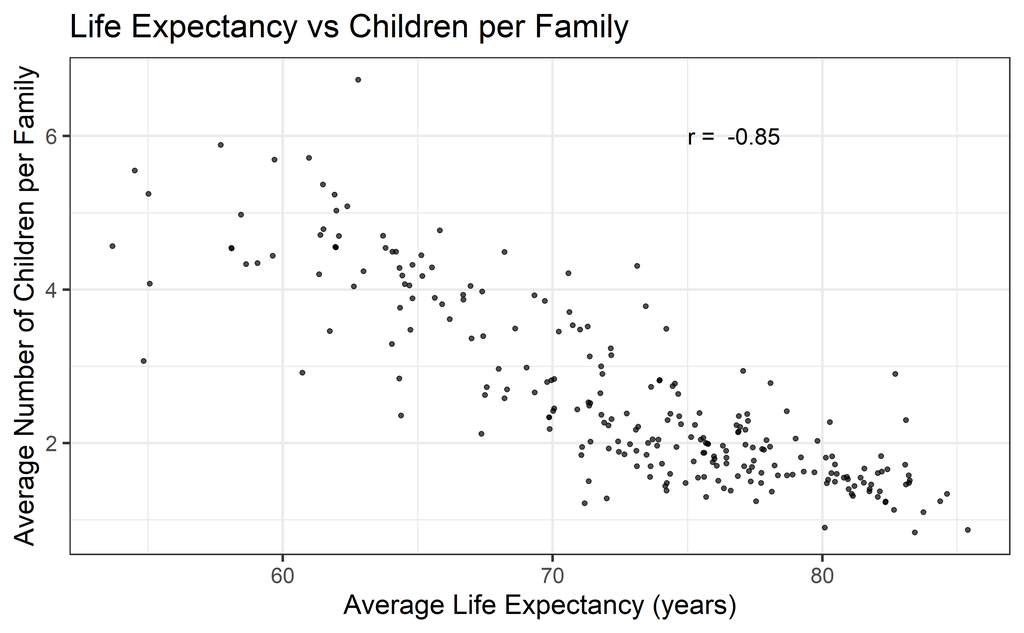

```r
#Secondary Charts #2: Ave Life Expectancy vs Ave Family Size
family_size_data <- ChildrenPerFamilyData %>%
    clean_names() %>%
    mutate(kids_2020 = x2020) %>%
    filter(kids_2020 != "NA")


#View(family_size_data)

life_expectancy_data <- AveLifeExpectancyData %>%
    clean_names() %>%
    left_join(family_size_data, by = c("country_code" = 'country_code'))

corr <- cor(
    life_expectancy_data$x2020.x,
    life_expectancy_data$kids_2020,
    use = "complete.obs"
)
corLab <- paste("r = ", round(corr,2))

cor_plot <- ggplot(life_expectancy_data) +
    geom_point(aes(x = x2020.x, y = kids_2020), alpha = 0.7) +
    annotate(
        geom = 'text',
        x = 75, y = 6,
        label = corLab,
        hjust = 0, size = 6
    ) +
    labs(
        x = "Average Life Expectancy (years)",
        y = "Average Number of Children per Family",
        title = "Life Expectancy vs Children per Family"
    )

cor_plot
```

```r
#View(life_expectancy_data)

#add another plot connecting it to growth rate
```

Above is a scatter plot showing the correlation between average life expectancy in a country in years and the average number of children in a family by country. As you can see the correlation is quite strong and has a pearson correlation coefficient of 85% which is significant. Clearly the longer people expect to live, the less children they have. When your country’s average life expectancy is lower, then a life timeline is shortened as well. This mean you typically start having children at a younger age and your kids survival is much less than certain, therefore you have multiple children. Countries with a lower average life expectancy also have a lower GDP, translating to less available resources for citizens such as access to health care, education, and even birth control. All these factors result in higher average number of children per family and more children being born leads to a higher population growth rate. This explains the high correlation coefficient shown above.

## Diving Deeper

### Population Change

[figure not shown]

```r
#Secondary Maps:
 population_difference <- worldpop %>%
    select(Name,"1970","2022",Rank) %>%
    mutate(
        `2022` = as.numeric(`2022`),
        `1970` = as.numeric(`1970`),
        `2022` = `2022` / 10^3, # Population in Millions
        `1970` = `1970` / 10^3,
        difference_pop = (`2022` - `1970`)
    )

population_difference %>%
    # select(Name, difference_pop) %>%
    arrange(desc(`2022`)) %>%
    slice(1:20) %>%
    mutate(Name = fct_reorder(Name, `2022`)) %>%
    ggplot() +
    geom_segment((aes(y = Name, yend = Name, x = `1970`, xend = `2022`))) +
    geom_point(aes(y = Name, x = `1970`), size = 2.5, color = 'lightblue') +
    geom_point(aes(y = Name, x = `2022`), size = 2.5, color = 'steelblue') +
    scale_x_continuous(labels = scales::comma) +
    labs(x = 'Increase in Population in Millions',
         y = 'Country',
         color = 'Year',
         title = 'The Top 20 Countries in Population Growth',
         subtitle = "(1970 - 2022)"
         )
```

```r
#dumbell charts -- claire
```

### Health Care Factors

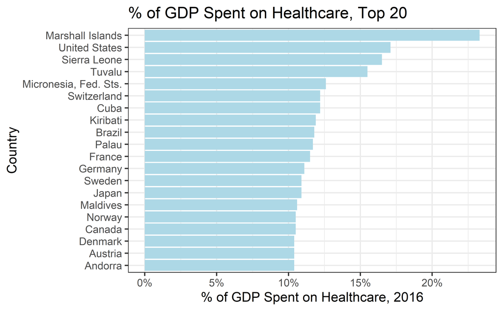

```r
Gdp_plot <- health_system %>%
    arrange(desc(`Health expenditure Current % of GDP 2016`)) %>%
    slice(1:20)

Gdp_plot  %>%
    select(`Health expenditure Current % of GDP 2016`, Country) %>%
    ggplot() +
    geom_col(aes(x = `Health expenditure Current % of GDP 2016`/100, y = reorder( Country,`Health expenditure Current % of GDP 2016`)), fill = "light blue") +
    scale_x_continuous(labels = scales::percent)+
    labs(
        title = "% of GDP Spent on Healthcare, Top 20",
        x = "% of GDP Spent on Healthcare, 2016",
        y = "Country"
    )
```

This graph displays the top 20 countries in healthcare expenses in % of GDP. This graph covers a portion of our research question through displaying the top 20 countries in healthcare expenses in % of GDP which allows us to compare the top 20 countries in this GDP stat to the countries with the highest growth rate. The majority of these countries in this graph are the most developed countries in the world such as the United States, Switzerland, Sweden, Germany, France, Canada, and Norway. This graph allows us to compare the 20 countries in this GDP stat to the top 20 countries in heath stats, other GDP stats, and avg. life expectancy. Utilizing those comparisons, we should be able to find countries that are in the top for multiple stats and compare how those countries stand in term of their growth rate among other countries.

https://worldpopulationreview.com/country-rankings/developed-countries

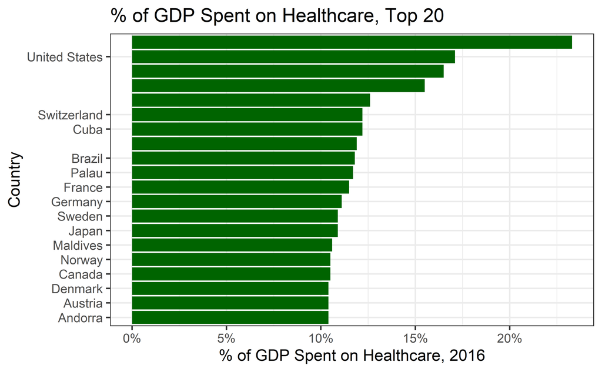

```r
#countrys with growth rate under 1%
Gdp_plot <- health_system %>%
    arrange(desc(`Health expenditure Current % of GDP 2016`)) %>%
    slice(1:20)

Gdp_plot  %>%
    select(`Health expenditure Current % of GDP 2016`, Country) %>%
    ggplot() +
    geom_col(aes(x = `Health expenditure Current % of GDP 2016`/100, y = reorder( Country,`Health expenditure Current % of GDP 2016`)), fill = "dark green") +
    scale_x_continuous(labels = scales::percent)+
    scale_y_discrete(
    breaks = c('United States', 'Switzerland', 'Cuba', "Brazil", 'Palau', 'France', 'Germany', 'Sweden', 'Japan', 'Maldives', 'Norway', 'Canada', 'Denmark', 'Austria', 'Andorra')) +
    labs(
        title = "% of GDP Spent on Healthcare, Top 20",
        x = "% of GDP Spent on Healthcare, 2016",
        y = "Country"
    )
```

The figure above is the same as the figure before, however, this time only the countries with a growth rate of under 1% are shown. Fifteen of the twenty countries with large percentages of their GDP spent on healthcare expenditures also have a pretty low growth rate. This signifies that there is a strong correlation between health care accessibility and a country’s population growth rate.

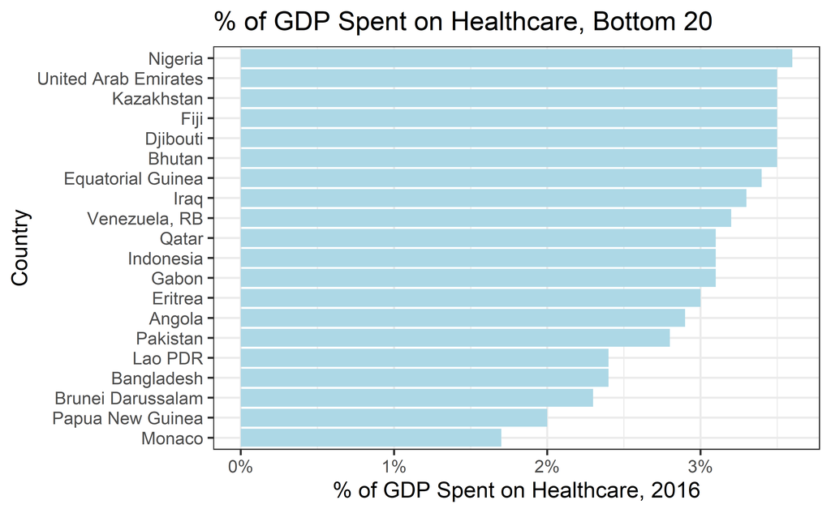

```r
Gdp_plot_least <- health_system %>%
    arrange((`Health expenditure Current % of GDP 2016`)) %>%
    slice(1:20)

Gdp_plot_least  %>%
    select(`Health expenditure Current % of GDP 2016`, Country) %>%
    ggplot() +
    geom_col(aes(x = `Health expenditure Current % of GDP 2016`/100, y = reorder( Country,`Health expenditure Current % of GDP 2016`)), fill = "light blue") +
    scale_x_continuous(labels = scales::percent) +
    labs(
        title = "% of GDP Spent on Healthcare, Bottom 20",
        x = "% of GDP Spent on Healthcare, 2016",
        y = "Country"
    )
```

This graph displays the lowest 20 countries in healthcare expenses in % of GDP. This graph covers a portion of our research question through allowing us to compare the lowest 20 countries in this GDP stat to the countries with the lowest growth rate. The majority of these countries in this graph are undeveloped countries in the world such as the Lao People’s Democratic Republic (Loa PDR), Papua New Guinea, Eritrea, Bangladesh, Bhutan,and Angola.This graph allows us to compare the lowest 20 countries in this GDP stat to the top 20 countries in heath stats, other GDP stats, and average life expectancy. Utilizing those comparisons, we should be able to find countries that have multiple low stats in common and compare how those countries stand in terms of their growth rate among other countries.

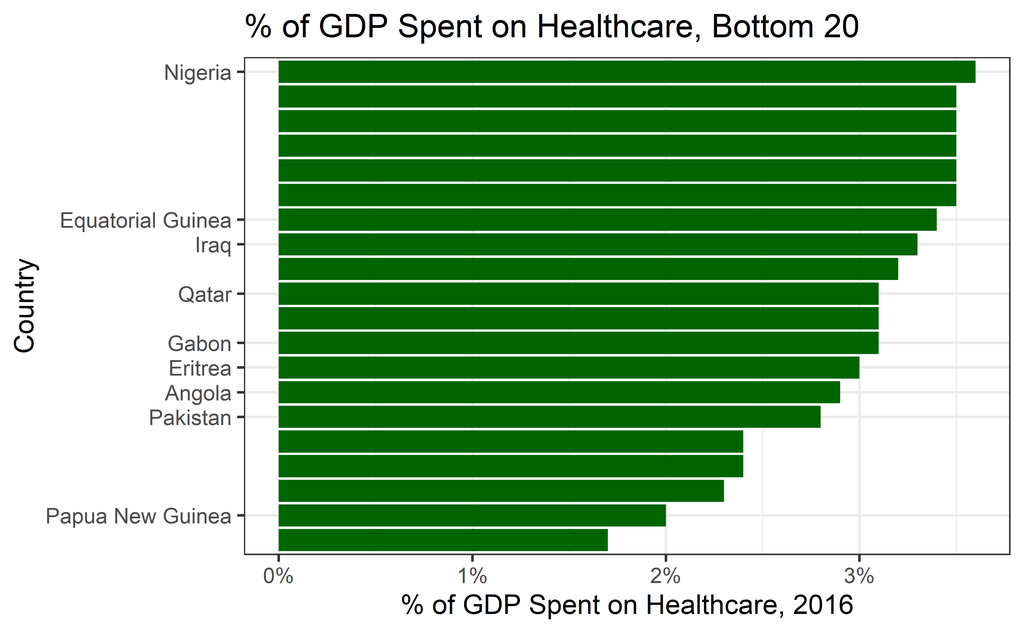

```r
#countries with a growth rate greater than 1.5%
Gdp_plot_least <- health_system %>%
    arrange((`Health expenditure Current % of GDP 2016`)) %>%
    slice(1:20)

Gdp_plot_least  %>%
    select(`Health expenditure Current % of GDP 2016`, Country) %>%
    ggplot() +
    geom_col(aes(x = `Health expenditure Current % of GDP 2016`/100, y = reorder( Country,`Health expenditure Current % of GDP 2016`)), fill = "dark green") +
    scale_x_continuous(labels = scales::percent) +
    scale_y_discrete(
    breaks = c('Nigeria', 'Equatorial Guinea', 'Iraq', "Qatar", 'Gabon', 'Eritrea', 'Angola', 'Pakistan', 'Japan', 'Maldives', 'Norway', 'Canada', 'Denmark', 'Papua New Guinea')) +
    labs(
        title = "% of GDP Spent on Healthcare, Bottom 20",
        x = "% of GDP Spent on Healthcare, 2016",
        y = "Country"
    )
```

# Conclusions

Overall, our analysis has provided valuable insights into the complex factors that influence population growth by country. While further research is needed to fully understand the mechanisms at play, our findings suggest that a combination of economic, social, and demographic factors play a critical role in determining population growth in different countries.

```r
#spelling::spell_check_files('report.Rmd')
```

# Appendix

### Dictionary for World Population Data Set:

| variable | class | description |
| --- | --- | --- |
| CCA3 | string | 3 Digit Country/Territories Code |
| Name | string | Name of the Country/Territories |
| 2022 | double | Population of the Country/Territories in year 2022 |
| 2020 | double | Population of the Country/Territories in year 2020 |
| 2015 | double | Population of the Country/Territories in year 2015 |
| 2010 | double | Population of the Country/Territories in year 2010 |
| 2000 | double | Population of the Country/Territories in year 2000 |
| 1990 | double | Population of the Country/Territories in year 1990 |
| 1980 | double | Population of the Country/Territories in year 1980 |
| 1970 | double | Population of the Country/Territories in year 1970 |
| Area (km²) | double | Area of the Country/Territories |
| Density (per km²) | double | Population density of Country/Territories |
| GrowthRate | double | The rate which the population is growing |
| World Population Percentage | double | The % the population of the country/territories makes up of the whole world population |
| Rank | double | What the country/territory ranks worldwide in population |

### Dictionary for Health Risk Factors Data Set:

| variable | class | description |
| --- | --- | --- |
| Country | string | Country/Territories |
| Prevalence of smoking Male % of adults 2016 | double | The percentages of males that smoke |
| Prevalence of smoking Female % of adults 2016 | double | The percentages of females that smoke |
| Incidence of tuberculosis per 100,000 people 2018 | double | The number of people out of 100,000 that have tuberculosis |
| Prevalence of diabetes % of population ages 20 to 79 2019 | double | The amount of people 20-79 with diabetes |
| Incidence of HIV Total per 1,000 uninfected population ages 15-49 2018 | double | The number of people per 1000 that have HIV |
| Prevalence of HIV Total % of population ages 15-49 2018 | double | The percentage of people that have HIV |
| Prevalence of HIV Women’s share of population ages 15+ living with HIV % 2018 | double | The number of women with HIV |
| Prevalence of HIV Youth, Male % of population ages 15-24 2018 | double | % of males with HIV |
| Prevalence of HIV Youth, Female % of population ages 15-24 2018 | double | % of women with HIV |
| Antiretroviral therapy coverage % of people living with HIV 2018 | double | % of people covered by HIV therapy |
| Cause of death Communicable diseases and maternal, prenatal, and nutrition conditions % of population 2016 | double | % of deaths caused by communicable diseases |
| Cause of death Non-communicable diseases % of population 2016 | double | % of death caused by non-communicable dieases |
| Cause of death Injuries % of population 2016 | double | % of death caused by injuries |

### Dictionary for GDP Data Set:

| variable | class | description |
| --- | --- | --- |
| Country Name | string | The name of the country |
| Country Code | string | 3 Digit Country/Territories Code |
| Indicator Name | string | Noting that the GDP values are in USD |
| Indicator Name | string | Noting that the GDP values are indicated |
| 1960-2021 | double | The GDP Values per country from 1960-2021 |

### Dictionary for Fertility Data Set:

| variable | class | description |
| --- | --- | --- |
| Country_Name | string | The name of the country |
| Country_Code | string | 3 Digit Country/Territories Code |
| Indicator_Name | string | Noting that the fertility rates are in total |
| Indicator_Name | string | Noting that the fertility rates are indicated |
| x1960-x2021 | double | The Fertility rates per country from 1960-2021 |

### Dictionary for Life Expectancy Data Set:

| variable | class | description |
| --- | --- | --- |
| Country_Name.x | string | The name of the country |
| Country_Code | string | 3 Digit Country/Territories Code |
| Indicator_Name.x | string | Noting that the life expectancy percentages are in total |
| Indicator_Name | string | Noting that the life expectancy rates are indicated |
| x1960.x-x2021.x | double | The life expectancy rates per country from 1960-2021 |